# R語言地科資料分析之應用

林柏伸 Person Lin

May 02, 2018

# 安裝R, RStudio及相關套件

[課程資料網址：https://github.com/personlin/Introduction-to-R-2018geo/](https://github.com/personlin/Introduction-to-R-2018geo/)

[軟體安裝介紹](https://yijutseng.github.io/DataScienceRBook/install.html)

1. [Install R 安裝R](https://cloud.r-project.org/)
2. [Install RStudio IDE 安裝RStudio整合開發軟體](https://www.rstudio.com/products/rstudio/download/#download)
- 安裝套件

```r
install.packages(c("maps", "ggmap", "dplyr", "rgdal", "leaflet", "geosphere",
                   "htmlwidgets", "xtable", "knitr",
                   "mapview", "automap", "here", "XML"))
```

# 學習R的理由

- 免錢(Free)與開放原始碼(Open Source)
- 跨平台，可以跑在Windows、Mac、Linux
- 搭上現在最夯的話題：Data Science、Big data…
- [Rank 6 of TOP 10 Programing Language in 2017(IEEE)](https://spectrum.ieee.org/computing/software/the-2017-top-programming-languages)

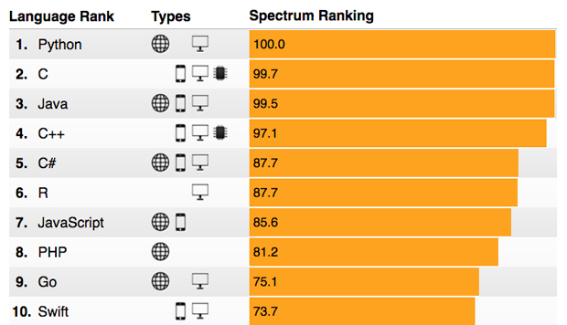

  [(Rank 5 in 2016,](http://spectrum.ieee.org/computing/software/the-2016-top-programming-languages) [Rank 6 in 2015)](http://spectrum.ieee.org/computing/software/the-2015-top-ten-programming-languages)

當然，你也可以學JAVA、C、Python…但我個人用R，所以我首推R (Python次之)。

# R的相關網頁

- [官方網頁https://www.r-project.org/](https://www.r-project.org/) 直接google “r”第一個結果就是!
- [RStudio](https://www.rstudio.com/) 寫R必備的IDE工具，找不到更好的了！
  - [rmarkdown](http://rmarkdown.rstudio.com/) R寫文件
  - [shiny](http://shiny.rstudio.com/) RStudio開發出來的架構，可以用R開發網頁應用。
  - [Rpubs](https://rpubs.com/) 用R寫出來的文件可以丟到上面分享。
- [RDocumentation](http://www.rdocumentation.org/) 搜尋R package & function 的好地方！！
- [R-blogger](https://www.r-bloggers.com/) 吸收R新知的地方
- [R Weekly](https://rweekly.org/) 另一個吸收R新知的地方
- [Awesome R](https://awesome-r.com/) A curated list of awesome R packages and tools.

# R的相關網頁-繪圖

- [The R graph gallery](https://www.r-graph-gallery.com/)
- [統計繪圖範例](http://vis.supstat.com/)
- [htmlwidgets](http://www.htmlwidgets.org/index.html) Bring the best of JavaScript data visualization to R
- [ggplot2說明文件](http://ggplot2.tidyverse.org/reference/)
  - [ggplot2 explorer](http://databall.co/shiny/shinyggplot/)
  - [ggplot2延伸套件展示](http://www.ggplot2-exts.org/gallery/)

# R的研討會useR

- [useR2018](https://user2018.r-project.org/)

[figure not shown]

# 台灣的R相關網站

- [國立台灣大學統計教學研究中心](http://www.statedu.ntu.edu.tw/chinese/index.asp)
- [李明昌 - 育達商業科技大學 資訊管理系 專任講師](http://web.ydu.edu.tw/~alan9956/)
- [中華R軟體學會 CARS](https://sites.google.com/site/zhonghuarruantixuehui/home)
- [陳鍾誠的網站 免費電子書 – R 統計軟體](http://ccckmit.wikidot.com/r:main)
- [R_note – The Exploration of Statistical Software R (統計軟體 R 深度歷險)](http://www.math.ncu.edu.tw/~chenwc/R_note/)
- [R語言翻轉教室(全中文R語言互動式教材)](http://datascienceandr.org/)

# 台灣的R相關網站 - 社群

- [Taiwan R User Group / MLDM Monday](https://www.meetup.com/Taiwan-R/)
- [R-LADIES TAIPEI](https://rladiestaipei.github.io/R-Ladies-Taipei/)

# 學習R的管道

- [Coursera線上課程](https://www.coursera.org/)

  英文發音但是有中文字幕！重點是不只有R的課程可以學，還有各式各樣的課程可以學習，連台大都有老師把課程放上去。(極推！)
- [TW Use-R社群 Youtube頻道](https://www.youtube.com/user/TWuseRGroup)

  之前的影片都有放上去了，近期的比較沒有，不過初學者應該看早期的也就夠了。
- [TW Use-R社群 Meetup聚會](http://www.meetup.com/Taiwan-R/)

  Machine Learning 和 Data Mining，星期一晚上在台北資策會數位教育研究所(捷運大安站)
- [R-Ladies Taipei](https://www.meetup.com/R-Ladies-Taipei/)

  女性學習社群(專屬)
- [stackoverflow](http://stackoverflow.com/questions/tagged/r)

  寫程式的時候遇到問題都可以來這裡找答案！

# 進階了解R

- [Advanced R](http://adv-r.had.co.nz/)

  R的神級高手Hadley Wickham[(個人網頁)](http://hadley.nz/)寫的，他目前在RStudio服務，寫了很多很厲害的package，如果可以把他寫的package都搞熟了，那差不多可以是半個神人了。
- [The tidyverse](http://tidyverse.org/)

  The tidyverse is a collection of R packages that share common philosophies and are designed to work together.

[figure not shown]

[figure not shown]

[figure not shown]

[figure not shown]

[figure not shown]

[figure not shown]

[figure not shown]

[figure not shown]

[figure not shown]

[figure not shown]

[figure not shown]

[figure not shown]

# R的書籍

- [Books related to R](https://www.r-project.org/doc/bib/R-books.html) 官網
- [R in a nutshell](http://amzn.com/059680170X), Joseph Adler.
- [Data manipulation with R](http://amzn.com/0387747303), Phil Spector.
- [Software for Data Analysis: Programming with R](http://amzn.com/0387759352), John Chambers.
- [R in Action](http://www.amazon.com/R-Action-Robert-Kabacoff/dp/1935182390)
- [The Art of R Programming: A Tour of Statistical Software Design](http://www.amazon.com/Art-Programming-Statistical-Software-Design/dp/1593273843) (R入門書)
- [R書精選12本](http://xccds1977.blogspot.tw/2013/02/r.html)
- [bookdown網站免費電子書](https://bookdown.org/) bookdown是謝益輝(Yihui Xie)開發的R寫電子書套件
- [資料科學與R語言](https://yijutseng.github.io/DataScienceRBook/) 由曾意儒老師撰寫(Yi-Ju Tseng)，是長庚資管大數據分析方法課程講義。(推薦)

我自己看的入門書是台北大學林建甫老師的「[醫學統計與R](http://web.ntpu.edu.tw/~cflin/Teach/R/Rproj.htm)」講義，跟[Data manipulation with R](http://amzn.com/0387747303)。

# R Packages推薦-1

- [dplyr](http://dplyr.tidyverse.org):A grammar of data manipulation [dplyr介紹](http://rpubs.com/tjmahr/dplyr_2015)
- RMySQL：跟MySQL資料庫連結
- RSQLite：跟SQLite資料庫連結
- sqldf：在R裡面使用SQL語法
- [ggplot2](http://ggplot2.tidyverse.org/)：畫圖的好套件！
- rgl：3D畫圖
- RFOC：地震震源機制
- [htmlwidgets](http://www.htmlwidgets.org/)：網頁互動套件
- httr：跟網頁溝通
- maptools：畫地圖

# R Packages推薦-2

- ggmap：用ggplot的style畫地圖
- [shiny](https://shiny.rstudio.com/)：網頁互動
- [rmarkdown](http://rmarkdown.rstudio.com/)：markdown for R
- devtools：開發工具
- showtext：中文字on圖
- magrittr:Ceci n’est pas un pipe. ‘%>%’ pipeline operation in R
  - [Let the Data Flow: Pipelines in R with dplyr and magrittr](https://github.com/tjmahr/MadR_Pipelines)
  - [Pipelines in R](http://rpubs.com/tjmahr/pipelines_2015)
  - [Pretty Tables with Pipelines](http://rpubs.com/tjmahr/prettytables_2015)

# R Packages推薦-3

出處：[10 R packages I wish I knew about earlier](http://blog.yhathq.com/posts/10-R-packages-I-wish-I-knew-about-earlier.html) by yhat (February 10, 2013)

- [sqldf](http://cran.r-project.org/web/packages/sqldf/index.html) Description: Manipulate R data frames using SQL.
- [forecast](http://cran.r-project.org/web/packages/forecast/index.html)
- [plyr](http://cran.r-project.org/web/packages/plyr/index.html)
- [stringr](http://cran.r-project.org/web/packages/stringr/index.html)
- The database driver package of your choice
  - install.packages(“RPostgreSQL”)
  - install.packages(“RMySQL”)
  - install.packages(“RMongo”)
  - install.packages(“RODBC”)
  - install.packages(“RSQLite”)
- [lubridate](http://cran.r-project.org/web/packages/lubridate/lubridate.pdf) 處理日期的套件
- [ggplot2](http://docs.ggplot2.org/current/)
- [qcc](http://cran.r-project.org/web/packages/qcc/index.html) qcc is a library for statistical quality control.
- [reshape2](http://cran.r-project.org/web/packages/reshape2/index.html)
- [randomForest](http://cran.r-project.org/web/packages/randomForest/index.html)
- [Random Forest資訊網站 (學習Random Forest方法)](http://www.stat.berkeley.edu/~breiman/RandomForests/)

# R地科相關應用套件

- [Introduction to R for the Geosciences](http://www.fromthebottomoftheheap.net/teaching/courses/mcmaster_2013/mcmaster_2013.html)
- [使用R來做地震分析 Convert to R for Seismic Analysis.pdf](http://www.unc.edu/~leesj/FETCH/GRAB/Vignettes/whyRbeam.pdf)
- [Statistical Seismology Library](http://homepages.maxnet.co.nz/davidharte/SSLib/) 地震統計學
- [ETAS (Modeling earthquake data using Epidemic Type Aftershock Sequence model](http://cran.r-project.org/web/packages/ETAS/index.html)
- [GRTo: Tools for the analysis of Gutenberg-Richter distributions of earthquake magnitudes](http://cran.r-project.org/web/packages/GRTo/index.html)

# 特別介紹

- Jonathan M. Lees
- Professor, Department Chair, Department of Geological Sciences, University of North Carolina at Chapel Hill
- [個人網頁http://www.unc.edu/~leesj/](http://www.unc.edu/~leesj/)
- 開發的套件
  - RSEIS:Seismic Analysis, Time Series
  - GEOmap:Geological Mapping, GIS
  - ProfessR:Create Exams, Grading
  - RFOC:Focal Mechanisms, statistics on a sphere
  - RPMG:Really Poor Man’s GUI
  - zoeppritz:scattering at an interface
  - RTOMO:visualization of tomographic inversions

# 安裝說明

[interactive chart not shown]

**R統計軟體 -安裝與使用** from **Person Lin**

# R安裝步驟

1.安裝R-3.4.1-win.exe https://cloud.r-project.org/bin/windows/base/R-3.4.1-win.exe

2.安裝Rtools34.exe https://cloud.r-project.org/bin/windows/Rtools/Rtools34.exe

3.安裝RStudio Desktop 1.0.143 https://download1.rstudio.org/RStudio-1.0.143.exe

4.安裝套件 install.packages(c(“Cairo”,“curl”,“devtools”,“dplyr”,“DT”,“formatR”,“fst”,“ggalt”,“ggmap”,“ggplot2”, “gtools”,“htmlwidgets”,“httr”,“LaF”,“leaflet”,“lme4”,“magick”,“maptools”,“mapdata”,“mapview”, “openxlsx”,“prettydoc”,“proj4”,“RCurl”,“readr”,“RFOC”,“rgdal”,“rgeos”,“rgl”,“rio”,“RJSONIO”, “rmarkdown”,“RMessenger”,“RMySQL”,“roxygen2”,“RSQLite”,“rvest”,“shiny”,“shinyBS”,“shinythemes”, “showtext”,“slackr”,“sqldf”,“testthat”,“XML”))

# demo

隨機取常態分佈N(0,1)的10個數。

```r
rnorm(10)
```

```
##  [1]  0.3719541 -0.5430406  1.2172260 -0.6678287 -1.0094533 -0.1478687
##  [7]  0.1514410 -0.4771496  1.2737850 -0.2158117
```

隨機取常態分佈N(0,1)的1000個數，然後畫直方圖(histogram)。

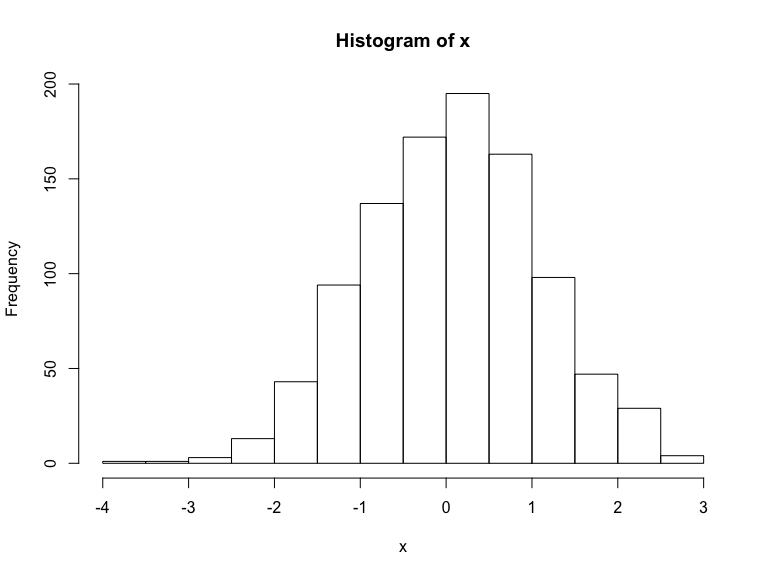

```r
x <- rnorm(1000,0,1)
hist(x)
```

# demo

鳶尾花的數據集

```r
data(iris) #載入資料
head(iris) #查看最前面6行資料
```

```
##   Sepal.Length Sepal.Width Petal.Length Petal.Width Species
## 1          5.1         3.5          1.4         0.2  setosa
## 2          4.9         3.0          1.4         0.2  setosa
## 3          4.7         3.2          1.3         0.2  setosa
## 4          4.6         3.1          1.5         0.2  setosa
## 5          5.0         3.6          1.4         0.2  setosa
## 6          5.4         3.9          1.7         0.4  setosa
```

# demo

用R畫鳶尾花的數據集

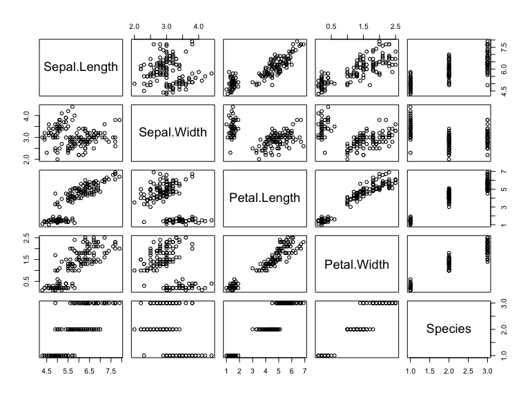

```r
plot(iris) #畫圖
```

# demo

地圖

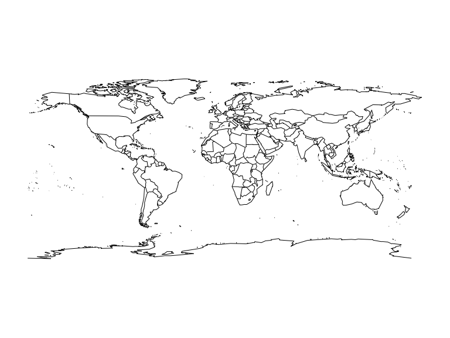

```r
library(maps)
map()
```

# demo|ggmap

[figure not shown]

```r
library(ggmap)
gm = get_map(location=c(121.25,24.9,121.8,25.3))
ggmap(gm)
```

# demo|ggmap

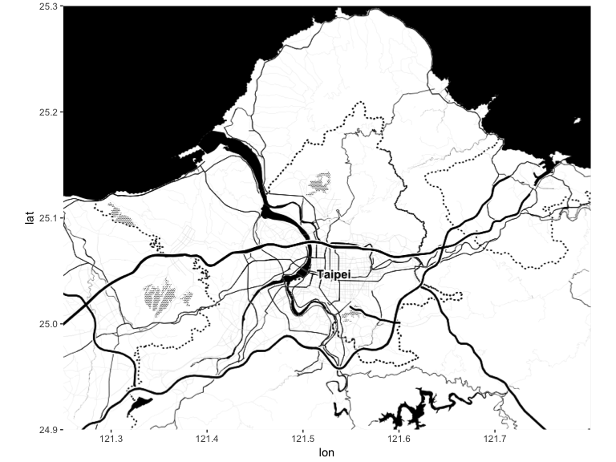

```r
gm2 = get_map(location=c(121.25,24.9,121.8,25.3), source="stamen",maptype="toner")
ggmap(gm2)
```

# demo|ggmap

[figure not shown]

```r
#from <- "106台北市大安區捷運台電大樓站"
from <- "Taipower Building Station, Taiwan"
#to <- "11008台北市信義區市府路1號台北市政府"
to <- "MRT Taipei City Hall, Taiwan"

route_df <- route(from, to, structure = 'route', mode = "walk")
qmap('Taipei', zoom = 13) +
  geom_path(
    aes(x = lon, y = lat), colour = 'red', size = 1.5,
    data = route_df, lineend = 'round')
```

# 如何用R寫投影片

slidify套件範例

http://www.jvcasillas.com/slidify_tutorial/

# R還可以…

- 使用[Shiny](https://shiny.rstudio.com/)建立數據的[互動式圖表](https://shiny.rstudio.com/gallery/): [Nepal quake](https://asheshwor.shinyapps.io/np-quake/)
- [devtools](https://www.rstudio.com/products/rpackages/devtools/)開發R語言套件pacakge: GMPEhaz
- [knitr](https://yihui.name/knitr/)、[rmarkdown](https://rmarkdown.rstudio.com/)建立報告、簡報、網站
- [knitr](https://yihui.name/knitr/)、[bookdown](https://bookdown.org/yihui/bookdown/)撰寫電子書
- [knitr](https://yihui.name/knitr/)、[blogdown](https://bookdown.org/yihui/blogdown/)建立個人blog:[Prof. Yi-Ju Tseng](https://yjtseng.info/)

# 可以開始寫程式了！！！